# POLS 2972Q

Quantitative Analysis in Political Science

Lecture 15 |

Predicting Non-Binary Outcomes Using Linear Regression

## Today’s Question

In the linear model $\hat{Y} = \hat{\alpha} + \hat{\beta}X$, the intercept coefficient, $\hat{\alpha}$, can be interpreted as:

A. the predicted Y when X=0

B. the expected change in the predicted Y when X=0

C. the predicted Y when X increases by one

D. the expected change in the predicted Y when X increases by one

## Plan for Today

- Prediction and Linear Regression
- Example with Non-binary Outcome Variable: Using Midterm Scores to Predict Final Exam Scores

A. Load and explore data

B. Identify X and Y

C. What is the relationship between X and Y? (scatter plot and correlations)

D. Fit a linear model using the least squares method

E. Interpret coefficients

F. Make predictions

G. Measure how well the model fits the data

## Using Midterm Scores to Predict Final Exam Scores

- Today we will analyze student performance data
- Our goal is to model the relationship between midterm and final exam scores
- So that we can later predict final exam scores based on midterm scores

**1. Load and explore data**

```r
data <- read.csv("grades.csv")

head(data)
```

```
  midterm final overall gradeA
1   79.25 47.00    69.2      0
2   96.25 87.75    94.3      1
3   58.25 37.75    62.0      0
4   54.50 62.00    72.4      0
5   83.00 39.75    72.4      0
6   41.75 49.50    59.5      0
```

- What’s the unit of observation?

**2. Identify X and Y**

- The predictor (X) is the variable we want to use to predict the outcome (Y)
  - In this case, the predictor is midterm
  - Let’s visualize the distribution of midterm

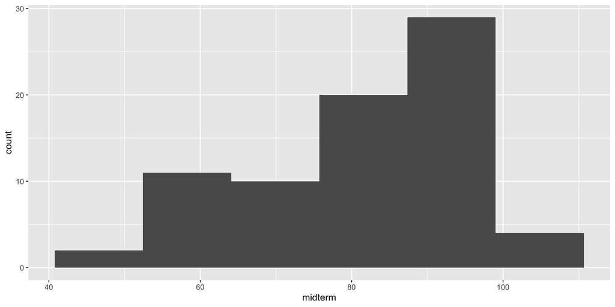

```r
ggplot(data = data) +
  geom_histogram(mapping = aes(x = midterm), bins = 6)
```

- The outcome (Y) is the variable that we want to predict
  - In this case, the outcome variable is final
  - Let’s visualize the distribution of final

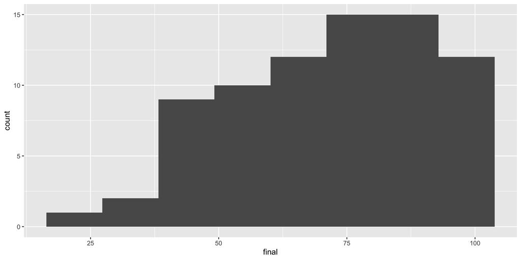

```r
ggplot(data = data) +
  geom_histogram(mapping = aes(x = final), bins = 8)
```

**3. What is the relationship between X and Y?**

- Create scatter plot to visualize the relationship between midterm and final

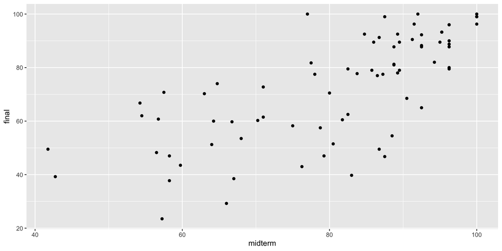

```r
ggplot(data = data) +
  geom_point(mapping = aes(x = midterm, y = final))
```

- What does each dot represent?
- Does the relationship look positive or negative?
- Does the relationship look weekly or strongly linear?
- Calculate correlation to measure direction and strength of linear association between midterm and final

```r
cor(data$midterm, data$final)
```

```
[1] 0.7160323
```

- We find a moderately strong positive correlation
- Are we surprised by this number?
- Based on the scatter plot and the correlation between midterm and final we learn that an increase in midterm scores is associated with an increase in final scores
- What we want to know is: **when midterm scores increase, by how much are final scores predicted to increase?**
- In general we care about: when X increases by one unit, by how much is Y predicted to change?
- To answer this question, we will fit a line to summarize the relationship between X and Y

**4. Fit a linear model using the least squares method**

- Which line better summarizes the relationship?

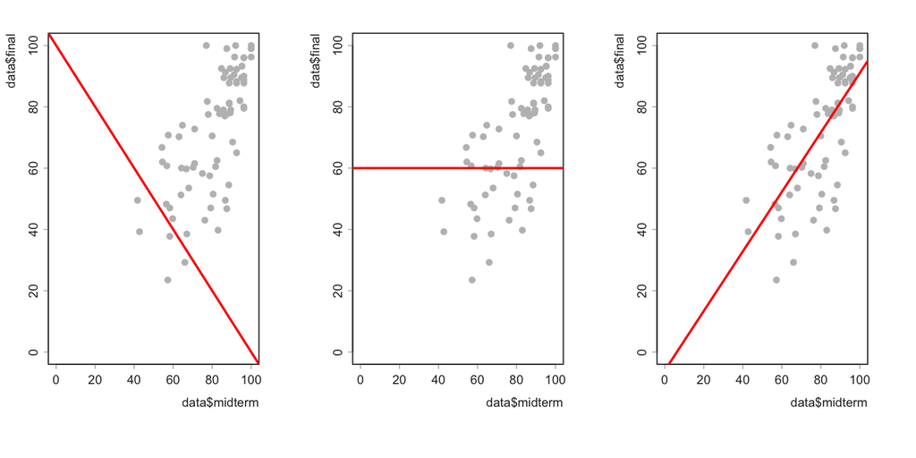

- The goal is the choose the line that best fits the data
  - Pick the line closest to the data
  - Which has the smallest prediction errors (vertical distance between dots and the line)?
- To choose the line that best fits the data, we use the **least squares method**:
  - Chooses the line that minimizes prediction errors
  - In particular, it minimizes $\sum_{i=1}^n$ $\hat{\varepsilon}^2$
    - Which is the sum of the squared of the prediction errors / residuals

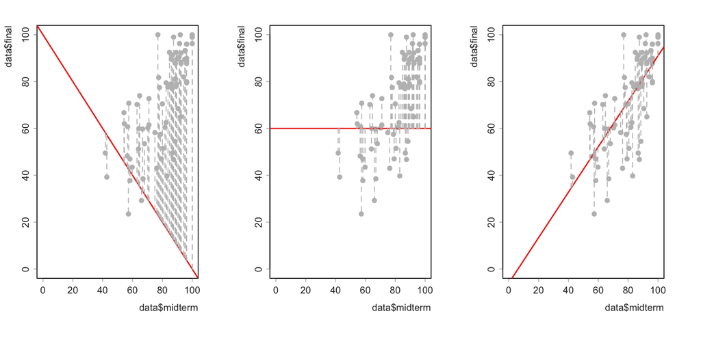

- A line is defined by two coefficients:
  - **Intercept** specifies the vertical location of the line
  - **Slope** specifies the angle or steepness of the line
- Mathematically: the fitted line is **$\hat{Y} = \hat{\alpha} + \hat{\beta}X$**
  - **$\alpha$** is the intercept
  - **$\beta$** is the slope
- If you learned that a line was $Y = mX + b$
  - Think that m is now $\hat{\beta}$
  - Think that b is now $\hat{\alpha}$
- $\hat{}$ (called “hat”) stands for predicted or estimated
  - $\hat{Y}$ is the predicted outcome
  - $\hat{\alpha}$ and $\hat{\beta}$ are the estimated coefficients
- R function to fit a linear model: `lm()`
  - Required argument: a formula of the type `Y ~ X`

```r
lm(final ~ midterm, data = data)
```

```
Call:
lm(formula = final ~ midterm, data = data)

Coefficients:
(Intercept)      midterm
    -6.0059       0.9704
```

- $\hat{\alpha}$ = -6.01 and $\hat{\beta}$ = 0.97
- The fitted line is $\hat{Y} = -6.01 + 0.97X$
- More specifically: $\hat{final} = -6.01 + 0.97midterm$
- We can now add the fitted line to the scatter plot above
- First, we store the fitted line in an object called fit

```r
fit <- lm(final ~ midterm, data = data)
```

- Then, we can use the function `abline()` or `geom_smooth()`
  - Require argument: name of object with fitted line

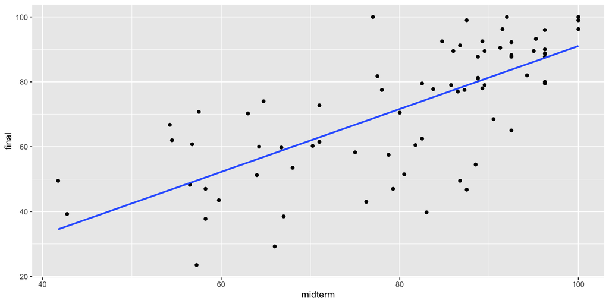

```r
#tidyverse
ggplot(data = data, mapping = aes(x = midterm, y = final)) +
  geom_point() +
  geom_smooth(method = "lm", se = FALSE)
```

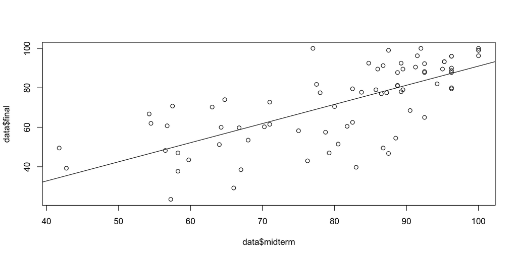

```r
#base R
plot(data$midterm, data$final)
abline(fit, color = "blue")
```

**5. Interpretation of Coefficients:**

- **The intercept ($\hat{\alpha}$) is the $\hat{Y}$ when X = 0**
- Find 0 on the X-axis, go up to the line, find the value of $\hat{Y}$ associated with X=0

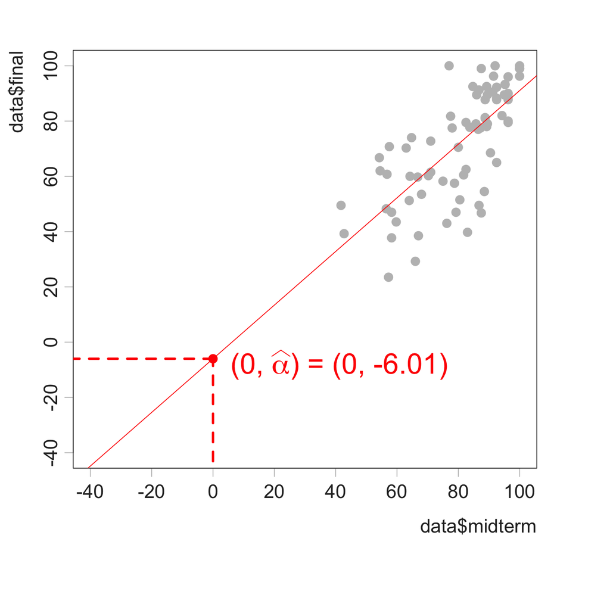

- Here: $\hat{\alpha}$ = -6.01

## Mathematical Definition of $\hat{\alpha}$

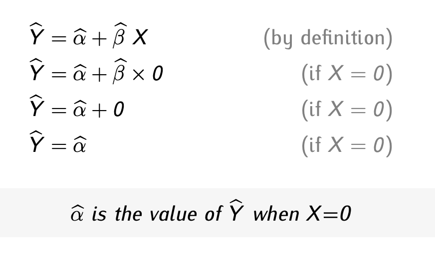

- Substantive interpretation of $\hat{\alpha}$
  - When a student scores 0 points in the midterm, we predict that in the final exam they will score -6.01 points, on average
- Sometimes it is nonsensical (due to extrapolation)
- Unit of measurement of $\hat{\alpha}$
  - Same as $\bar{Y}$
  - In this case, Y is non-binary and measured in points, so $\bar{Y}$ is measured in points and so is $\hat{\alpha}$
- **The slope ($\hat{\beta}$) is the $\bigtriangleup \hat{Y}$ associated with $\bigtriangleup X = 1$**
- Pick two points on the line, measure $\bigtriangleup \hat{Y}$ and $\bigtriangleup X$ associated with the two points, then calculate $\bigtriangleup \hat{Y}$ | $\bigtriangleup X$

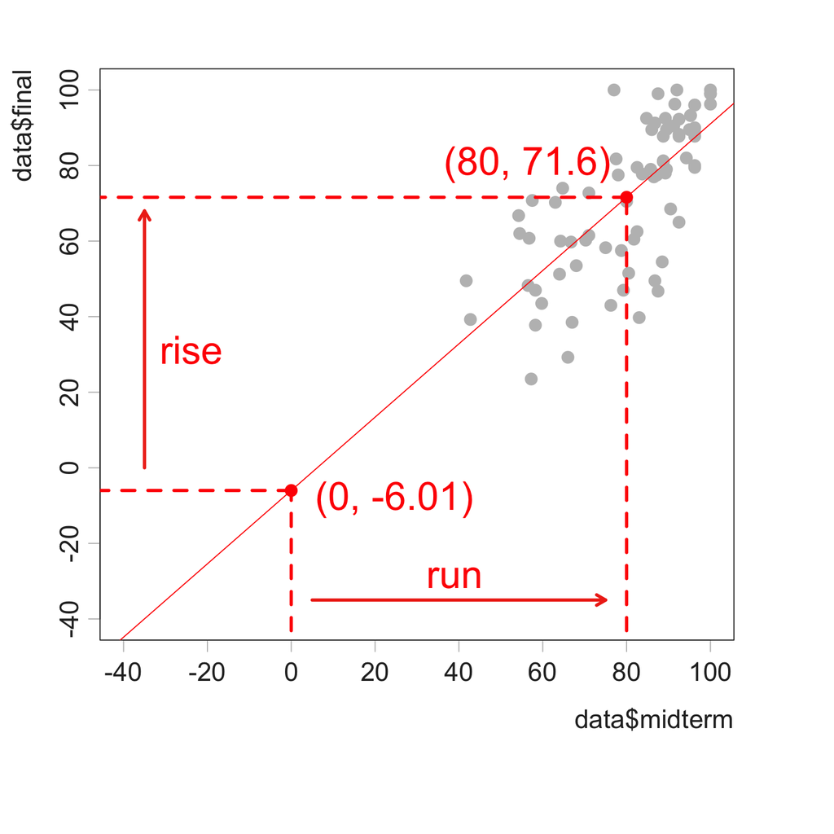

- Here: $\hat{\beta}$ = $\frac{rise}{run}$ = $\frac{71.6 - (-6.01)}{80 - 0}$ = $\frac{77.61}{80}$ = 0.97

$\bigtriangleup \hat{Y} = \hat{Y}final - \hat{Y}initial$

$\bigtriangleup X = Xfinal - Xinitial$

## Mathematical Definition of $\hat{\beta}$

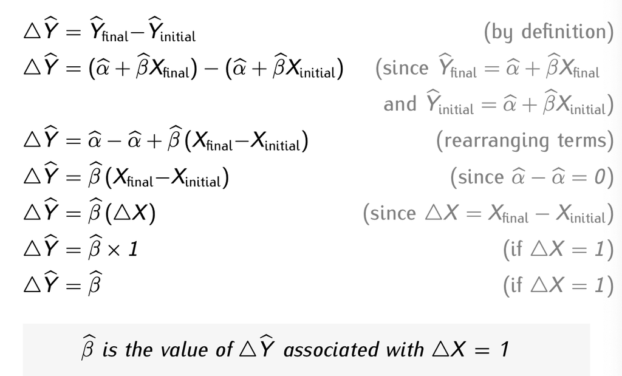

- Substantive interpretation of $\hat{\beta}$
  - $\hat{\beta}$ is the $\bigtriangleup \hat{Y}$ associated with a$\bigtriangleup \hat{X}$ = 1
  - An increase in midterm scores of 1 point is associated with a predicted increase in final exam scores of 0.97 points, on average
  - Has the same sign as the `cor(x,y)` (always the case)
- Unit of measurement of $\hat{\beta}$
  - Same as $\bigtriangleup \bar{Y}$
  - In this case, Y is non-binary and measured in points so $\bigtriangleup \bar{Y}$ is measure in points and so is $\hat{\beta}$
- **The Fitted Line Is**

$\hat{Y} = \hat{\alpha} + \hat{\beta}X$

- $\hat{\alpha}$ (alpha-hat) is the estimated intercept coefficient the $\hat{Y}$ when X = 0
- $\hat{\beta}$ (beta-hat) is the estimated intercept coefficient the $\bigtriangleup \bar{Y}$ when $\bigtriangleup \bar{X}$ = 1

**6. Make Predictions**

- Now that we have found the line that best summarizes the relationship between X and Y, we can use it to make predictions
- There are two types of predictions that we might be interested in
  - Predict $\hat{Y}$ based on X: $\hat{Y} = \hat{\alpha} + \hat{\beta}X$
  - Predict $\bigtriangleup \hat{Y}$ associated with $\bigtriangleup X$: $\bigtriangleup \hat{Y}$ = $\hat{\beta}\bigtriangleup X$
- To predict $\hat{Y}$ based on X: $\hat{Y} = \hat{\alpha} + \hat{\beta}X$
- Example 1: Imagine you earn 80 points in the midterm, what would we predict your final exam score will be?

$\hat{final} = -6.01 + 0.97midterm$

$\hat{final} = -6.01 + 0.97 \times 80$ (if midterm = 80)

$\hat{final} = 71.59$

- Therefore, if you earn 80 points in the midterm, we would predict that you will earn 71.59 points in the final exam, on average
- Note: $\hat{Y}$ is the same unit of measurement as $\bar{Y}$
  - In this case, Y is non-binary and measure in points so $\bar{Y}$ and $\hat{Y}$ are also measured in points
- Example 2: Imagine you earn 90 points in the midterm, what would we predict your final exam score will be?

$\hat{final} = -6.01 + 0.97midterm$

$\hat{final} = -6.01 + 0.97 \times 90$ (if midterm = 90)

$\hat{final} = 81.29$

- Therefore, if you earn 90 points in the midterm, we would predict that you will earn 81.29 points in the final exam, on average
- To predict $\bigtriangleup \hat{Y}$ associated with $\bigtriangleup X$: $\bigtriangleup \hat{Y}$ = $\hat{\beta}\bigtriangleup X$
- Example 3: If you increase your midterm scores by 10 points, by how much would we predict that your final exam scores would change?

$\bigtriangleup\hat{final} = 0.97\bigtriangleup midterm$

$\bigtriangleup\hat{final} = 0.97 \times 10$ (if $\bigtriangleup$ midterm = 10)

$\bigtriangleup\hat{final} = 9.7$

- Therefore, an increase of midterm scores of 10 points is associated with a predicted increase of final exam scores of 9.7 points, on average

**7. Measure how well the model fits the data with $R^2$**

- We will see how to do this next lecture